# Risk Factor Analysis

## Outcome Variable

**Outcome Variable:** ever_stunted

## Predictor Variables

**Intervention Variable:** enwast

**Adjustment Set:**

unadjusted

## Stratifying Variables

The analysis was stratified on these variable(s):

- agecat
- studyid
- country

## Data Summary

| agecat | studyid | country | enwast | ever_stunted | n_cell | n |
| --- | --- | --- | --- | --- | --- | --- |
| 0-6 months | ki0047075b-MAL-ED | BANGLADESH | 0 | 0 | 174 | 241 |
| 0-6 months | ki0047075b-MAL-ED | BANGLADESH | 0 | 1 | 27 | 241 |
| 0-6 months | ki0047075b-MAL-ED | BANGLADESH | 1 | 0 | 36 | 241 |
| 0-6 months | ki0047075b-MAL-ED | BANGLADESH | 1 | 1 | 4 | 241 |
| 0-6 months | ki0047075b-MAL-ED | BRAZIL | 0 | 0 | 163 | 183 |
| 0-6 months | ki0047075b-MAL-ED | BRAZIL | 0 | 1 | 14 | 183 |
| 0-6 months | ki0047075b-MAL-ED | BRAZIL | 1 | 0 | 6 | 183 |
| 0-6 months | ki0047075b-MAL-ED | BRAZIL | 1 | 1 | 0 | 183 |
| 0-6 months | ki0047075b-MAL-ED | INDIA | 0 | 0 | 146 | 203 |
| 0-6 months | ki0047075b-MAL-ED | INDIA | 0 | 1 | 24 | 203 |
| 0-6 months | ki0047075b-MAL-ED | INDIA | 1 | 0 | 27 | 203 |
| 0-6 months | ki0047075b-MAL-ED | INDIA | 1 | 1 | 6 | 203 |
| 0-6 months | ki0047075b-MAL-ED | NEPAL | 0 | 0 | 136 | 169 |
| 0-6 months | ki0047075b-MAL-ED | NEPAL | 0 | 1 | 12 | 169 |
| 0-6 months | ki0047075b-MAL-ED | NEPAL | 1 | 0 | 19 | 169 |
| 0-6 months | ki0047075b-MAL-ED | NEPAL | 1 | 1 | 2 | 169 |
| 0-6 months | ki0047075b-MAL-ED | PERU | 0 | 0 | 248 | 279 |
| 0-6 months | ki0047075b-MAL-ED | PERU | 0 | 1 | 25 | 279 |
| 0-6 months | ki0047075b-MAL-ED | PERU | 1 | 0 | 5 | 279 |
| 0-6 months | ki0047075b-MAL-ED | PERU | 1 | 1 | 1 | 279 |
| 0-6 months | ki0047075b-MAL-ED | SOUTH AFRICA | 0 | 0 | 218 | 260 |
| 0-6 months | ki0047075b-MAL-ED | SOUTH AFRICA | 0 | 1 | 22 | 260 |
| 0-6 months | ki0047075b-MAL-ED | SOUTH AFRICA | 1 | 0 | 16 | 260 |
| 0-6 months | ki0047075b-MAL-ED | SOUTH AFRICA | 1 | 1 | 4 | 260 |
| 0-6 months | ki0047075b-MAL-ED | TANZANIA, UNITED REPUBLIC OF | 0 | 0 | 104 | 118 |
| 0-6 months | ki0047075b-MAL-ED | TANZANIA, UNITED REPUBLIC OF | 0 | 1 | 12 | 118 |
| 0-6 months | ki0047075b-MAL-ED | TANZANIA, UNITED REPUBLIC OF | 1 | 0 | 1 | 118 |
| 0-6 months | ki0047075b-MAL-ED | TANZANIA, UNITED REPUBLIC OF | 1 | 1 | 1 | 118 |
| 0-6 months | ki1000108-CMC-V-BCS-2002 | INDIA | 0 | 0 | 65 | 92 |
| 0-6 months | ki1000108-CMC-V-BCS-2002 | INDIA | 0 | 1 | 9 | 92 |

[output cut: 344 more lines]

The following strata were considered:

- agecat: 0-24 months, studyid: ki0047075b-MAL-ED, country: BANGLADESH
- agecat: 0-24 months, studyid: ki0047075b-MAL-ED, country: BRAZIL
- agecat: 0-24 months, studyid: ki0047075b-MAL-ED, country: INDIA
- agecat: 0-24 months, studyid: ki0047075b-MAL-ED, country: NEPAL
- agecat: 0-24 months, studyid: ki0047075b-MAL-ED, country: PERU
- agecat: 0-24 months, studyid: ki0047075b-MAL-ED, country: SOUTH AFRICA
- agecat: 0-24 months, studyid: ki0047075b-MAL-ED, country: TANZANIA, UNITED REPUBLIC OF
- agecat: 0-24 months, studyid: ki1000108-CMC-V-BCS-2002, country: INDIA
- agecat: 0-24 months, studyid: ki1000108-IRC, country: INDIA
- agecat: 0-24 months, studyid: ki1000109-EE, country: PAKISTAN
- agecat: 0-24 months, studyid: ki1000109-ResPak, country: PAKISTAN
- agecat: 0-24 months, studyid: ki1000304b-SAS-CompFeed, country: INDIA
- agecat: 0-24 months, studyid: ki1000304b-SAS-FoodSuppl, country: INDIA
- agecat: 0-24 months, studyid: ki1017093-NIH-Birth, country: BANGLADESH
- agecat: 0-24 months, studyid: ki1017093c-NIH-Crypto, country: BANGLADESH
- agecat: 0-24 months, studyid: ki1066203-TanzaniaChild2, country: TANZANIA, UNITED REPUBLIC OF
- agecat: 0-24 months, studyid: ki1101329-Keneba, country: GAMBIA
- agecat: 0-24 months, studyid: ki1112895-Guatemala BSC, country: GUATEMALA
- agecat: 0-24 months, studyid: ki1112895-iLiNS-Zinc, country: BURKINA FASO
- agecat: 0-24 months, studyid: ki1113344-GMS-Nepal, country: NEPAL
- agecat: 0-24 months, studyid: ki1114097-CMIN, country: BANGLADESH
- agecat: 0-24 months, studyid: ki1114097-CMIN, country: BRAZIL
- agecat: 0-24 months, studyid: ki1114097-CMIN, country: GUINEA-BISSAU
- agecat: 0-24 months, studyid: ki1114097-CMIN, country: PERU
- agecat: 0-24 months, studyid: ki1114097-CONTENT, country: PERU
- agecat: 0-24 months, studyid: ki1119695-PROBIT, country: BELARUS
- agecat: 0-24 months, studyid: ki1126311-ZVITAMBO, country: ZIMBABWE
- agecat: 0-24 months, studyid: ki1135781-COHORTS, country: GUATEMALA
- agecat: 0-24 months, studyid: ki1135781-COHORTS, country: INDIA
- agecat: 0-24 months, studyid: ki1135781-COHORTS, country: PHILIPPINES
- agecat: 0-24 months, studyid: ki1148112-LCNI-5, country: MALAWI
- agecat: 0-24 months, studyid: kiGH5241-JiVitA-3, country: BANGLADESH
- agecat: 0-24 months, studyid: kiGH5241-JiVitA-4, country: BANGLADESH
- agecat: 0-6 months, studyid: ki0047075b-MAL-ED, country: BANGLADESH
- agecat: 0-6 months, studyid: ki0047075b-MAL-ED, country: BRAZIL
- agecat: 0-6 months, studyid: ki0047075b-MAL-ED, country: INDIA
- agecat: 0-6 months, studyid: ki0047075b-MAL-ED, country: NEPAL
- agecat: 0-6 months, studyid: ki0047075b-MAL-ED, country: PERU
- agecat: 0-6 months, studyid: ki0047075b-MAL-ED, country: SOUTH AFRICA
- agecat: 0-6 months, studyid: ki0047075b-MAL-ED, country: TANZANIA, UNITED REPUBLIC OF
- agecat: 0-6 months, studyid: ki1000108-CMC-V-BCS-2002, country: INDIA
- agecat: 0-6 months, studyid: ki1000108-IRC, country: INDIA
- agecat: 0-6 months, studyid: ki1000109-EE, country: PAKISTAN
- agecat: 0-6 months, studyid: ki1000109-ResPak, country: PAKISTAN
- agecat: 0-6 months, studyid: ki1000304b-SAS-CompFeed, country: INDIA
- agecat: 0-6 months, studyid: ki1000304b-SAS-FoodSuppl, country: INDIA
- agecat: 0-6 months, studyid: ki1017093-NIH-Birth, country: BANGLADESH
- agecat: 0-6 months, studyid: ki1017093c-NIH-Crypto, country: BANGLADESH
- agecat: 0-6 months, studyid: ki1066203-TanzaniaChild2, country: TANZANIA, UNITED REPUBLIC OF
- agecat: 0-6 months, studyid: ki1101329-Keneba, country: GAMBIA
- agecat: 0-6 months, studyid: ki1112895-Guatemala BSC, country: GUATEMALA
- agecat: 0-6 months, studyid: ki1113344-GMS-Nepal, country: NEPAL
- agecat: 0-6 months, studyid: ki1114097-CMIN, country: BANGLADESH
- agecat: 0-6 months, studyid: ki1114097-CMIN, country: BRAZIL
- agecat: 0-6 months, studyid: ki1114097-CMIN, country: GUINEA-BISSAU
- agecat: 0-6 months, studyid: ki1114097-CMIN, country: PERU
- agecat: 0-6 months, studyid: ki1114097-CONTENT, country: PERU
- agecat: 0-6 months, studyid: ki1119695-PROBIT, country: BELARUS
- agecat: 0-6 months, studyid: ki1126311-ZVITAMBO, country: ZIMBABWE
- agecat: 0-6 months, studyid: ki1135781-COHORTS, country: GUATEMALA
- agecat: 0-6 months, studyid: ki1135781-COHORTS, country: INDIA
- agecat: 0-6 months, studyid: ki1135781-COHORTS, country: PHILIPPINES
- agecat: 0-6 months, studyid: ki1148112-LCNI-5, country: MALAWI
- agecat: 0-6 months, studyid: kiGH5241-JiVitA-3, country: BANGLADESH
- agecat: 0-6 months, studyid: kiGH5241-JiVitA-4, country: BANGLADESH
- agecat: 6-24 months, studyid: ki0047075b-MAL-ED, country: BANGLADESH
- agecat: 6-24 months, studyid: ki0047075b-MAL-ED, country: BRAZIL
- agecat: 6-24 months, studyid: ki0047075b-MAL-ED, country: INDIA
- agecat: 6-24 months, studyid: ki0047075b-MAL-ED, country: NEPAL
- agecat: 6-24 months, studyid: ki0047075b-MAL-ED, country: PERU
- agecat: 6-24 months, studyid: ki0047075b-MAL-ED, country: SOUTH AFRICA
- agecat: 6-24 months, studyid: ki0047075b-MAL-ED, country: TANZANIA, UNITED REPUBLIC OF
- agecat: 6-24 months, studyid: ki1000108-CMC-V-BCS-2002, country: INDIA
- agecat: 6-24 months, studyid: ki1000108-IRC, country: INDIA
- agecat: 6-24 months, studyid: ki1000109-EE, country: PAKISTAN
- agecat: 6-24 months, studyid: ki1000109-ResPak, country: PAKISTAN
- agecat: 6-24 months, studyid: ki1000304b-SAS-CompFeed, country: INDIA
- agecat: 6-24 months, studyid: ki1000304b-SAS-FoodSuppl, country: INDIA
- agecat: 6-24 months, studyid: ki1017093-NIH-Birth, country: BANGLADESH
- agecat: 6-24 months, studyid: ki1017093c-NIH-Crypto, country: BANGLADESH
- agecat: 6-24 months, studyid: ki1066203-TanzaniaChild2, country: TANZANIA, UNITED REPUBLIC OF
- agecat: 6-24 months, studyid: ki1101329-Keneba, country: GAMBIA
- agecat: 6-24 months, studyid: ki1112895-Guatemala BSC, country: GUATEMALA
- agecat: 6-24 months, studyid: ki1112895-iLiNS-Zinc, country: BURKINA FASO
- agecat: 6-24 months, studyid: ki1113344-GMS-Nepal, country: NEPAL
- agecat: 6-24 months, studyid: ki1114097-CMIN, country: BRAZIL
- agecat: 6-24 months, studyid: ki1114097-CMIN, country: GUINEA-BISSAU
- agecat: 6-24 months, studyid: ki1114097-CMIN, country: PERU
- agecat: 6-24 months, studyid: ki1114097-CONTENT, country: PERU
- agecat: 6-24 months, studyid: ki1119695-PROBIT, country: BELARUS
- agecat: 6-24 months, studyid: ki1126311-ZVITAMBO, country: ZIMBABWE
- agecat: 6-24 months, studyid: ki1135781-COHORTS, country: GUATEMALA
- agecat: 6-24 months, studyid: ki1135781-COHORTS, country: INDIA
- agecat: 6-24 months, studyid: ki1135781-COHORTS, country: PHILIPPINES
- agecat: 6-24 months, studyid: ki1148112-LCNI-5, country: MALAWI
- agecat: 6-24 months, studyid: kiGH5241-JiVitA-3, country: BANGLADESH
- agecat: 6-24 months, studyid: kiGH5241-JiVitA-4, country: BANGLADESH

### Dropped Strata

Some strata were dropped due to rare outcomes:

- agecat: 0-6 months, studyid: ki0047075b-MAL-ED, country: BANGLADESH
- agecat: 0-6 months, studyid: ki0047075b-MAL-ED, country: BRAZIL
- agecat: 0-6 months, studyid: ki0047075b-MAL-ED, country: NEPAL
- agecat: 0-6 months, studyid: ki0047075b-MAL-ED, country: PERU
- agecat: 0-6 months, studyid: ki0047075b-MAL-ED, country: SOUTH AFRICA
- agecat: 0-6 months, studyid: ki0047075b-MAL-ED, country: TANZANIA, UNITED REPUBLIC OF
- agecat: 0-6 months, studyid: ki1000108-CMC-V-BCS-2002, country: INDIA
- agecat: 0-6 months, studyid: ki1000109-EE, country: PAKISTAN
- agecat: 0-6 months, studyid: ki1000109-ResPak, country: PAKISTAN
- agecat: 0-6 months, studyid: ki1017093c-NIH-Crypto, country: BANGLADESH
- agecat: 0-6 months, studyid: ki1066203-TanzaniaChild2, country: TANZANIA, UNITED REPUBLIC OF
- agecat: 0-6 months, studyid: ki1112895-Guatemala BSC, country: GUATEMALA
- agecat: 0-6 months, studyid: ki1113344-GMS-Nepal, country: NEPAL
- agecat: 0-6 months, studyid: ki1114097-CMIN, country: BANGLADESH
- agecat: 0-6 months, studyid: ki1114097-CMIN, country: BRAZIL
- agecat: 0-6 months, studyid: ki1114097-CMIN, country: GUINEA-BISSAU
- agecat: 0-6 months, studyid: ki1114097-CMIN, country: PERU
- agecat: 0-6 months, studyid: ki1119695-PROBIT, country: BELARUS
- agecat: 0-6 months, studyid: ki1135781-COHORTS, country: GUATEMALA
- agecat: 0-6 months, studyid: ki1148112-LCNI-5, country: MALAWI
- agecat: 6-24 months, studyid: ki0047075b-MAL-ED, country: BRAZIL
- agecat: 6-24 months, studyid: ki0047075b-MAL-ED, country: INDIA
- agecat: 6-24 months, studyid: ki0047075b-MAL-ED, country: NEPAL
- agecat: 6-24 months, studyid: ki0047075b-MAL-ED, country: PERU
- agecat: 6-24 months, studyid: ki0047075b-MAL-ED, country: SOUTH AFRICA
- agecat: 6-24 months, studyid: ki0047075b-MAL-ED, country: TANZANIA, UNITED REPUBLIC OF
- agecat: 6-24 months, studyid: ki1000108-CMC-V-BCS-2002, country: INDIA
- agecat: 6-24 months, studyid: ki1000109-EE, country: PAKISTAN
- agecat: 6-24 months, studyid: ki1000109-ResPak, country: PAKISTAN
- agecat: 6-24 months, studyid: ki1017093c-NIH-Crypto, country: BANGLADESH
- agecat: 6-24 months, studyid: ki1066203-TanzaniaChild2, country: TANZANIA, UNITED REPUBLIC OF
- agecat: 6-24 months, studyid: ki1112895-Guatemala BSC, country: GUATEMALA
- agecat: 6-24 months, studyid: ki1113344-GMS-Nepal, country: NEPAL
- agecat: 6-24 months, studyid: ki1114097-CMIN, country: BRAZIL
- agecat: 6-24 months, studyid: ki1114097-CMIN, country: GUINEA-BISSAU
- agecat: 6-24 months, studyid: ki1114097-CMIN, country: PERU
- agecat: 6-24 months, studyid: ki1114097-CONTENT, country: PERU
- agecat: 6-24 months, studyid: ki1148112-LCNI-5, country: MALAWI
- agecat: 0-24 months, studyid: ki0047075b-MAL-ED, country: BRAZIL
- agecat: 0-24 months, studyid: ki0047075b-MAL-ED, country: PERU
- agecat: 0-24 months, studyid: ki0047075b-MAL-ED, country: TANZANIA, UNITED REPUBLIC OF
- agecat: 0-24 months, studyid: ki1000108-CMC-V-BCS-2002, country: INDIA
- agecat: 0-24 months, studyid: ki1000109-EE, country: PAKISTAN
- agecat: 0-24 months, studyid: ki1000109-ResPak, country: PAKISTAN
- agecat: 0-24 months, studyid: ki1017093c-NIH-Crypto, country: BANGLADESH
- agecat: 0-24 months, studyid: ki1112895-Guatemala BSC, country: GUATEMALA
- agecat: 0-24 months, studyid: ki1113344-GMS-Nepal, country: NEPAL
- agecat: 0-24 months, studyid: ki1114097-CMIN, country: BANGLADESH
- agecat: 0-24 months, studyid: ki1114097-CMIN, country: BRAZIL
- agecat: 0-24 months, studyid: ki1114097-CMIN, country: PERU

## Methods Detail

We’re interested in the causal parameters $E[Y_a]$ for all values of $a \in \mathcal{A}$. These parameters represent the mean outcome if, possibly contrary to fact, we intervened to set all units to have $A=a$. Under the randomization and positivity assumptions, these are identified by the statistical parameters $\psi_a=E_W[E_{Y|A,W}(Y|A=a,W)]$. In addition, we’re interested in the mean of $Y$, $E[Y]$ under no intervention (the observed mean). We will estimate these parameters by using SuperLearner to fit the relevant likelihood factors – $E_{Y|A,W}(Y|A=a,W)$ and $p(A=a|W)$, and then updating our likelihood fit using a joint TMLE.

For unadjusted analyses ($W=\{\}$), initial likelihoods were estimated using Lrnr_glm to estimate the simple $E(Y|A)$ and Lrnr_mean to estimate $p(A)$. For adjusted analyses, a small library containing Lrnr_glmnet, Lrnr_xgboost, and Lrnr_mean was used.

Having estimated these parameters, we will then use the delta method to estimate relative risks and attributable risks relative to a prespecified baseline level of $A$.

[output not shown]

# Results Detail

## Results Plots

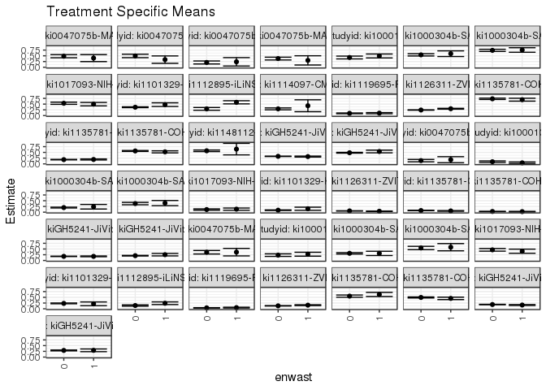

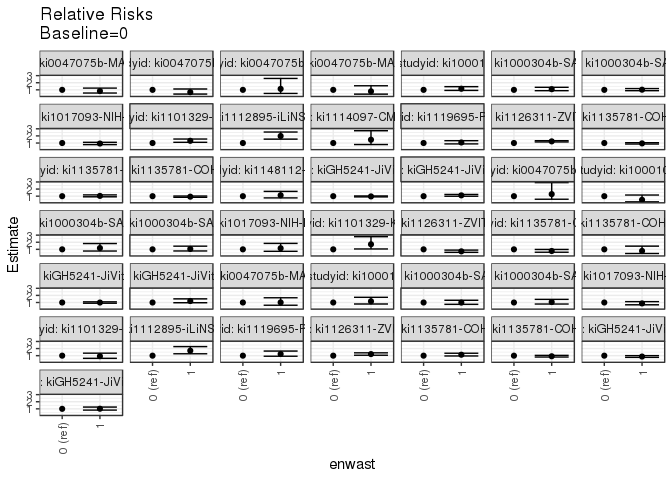

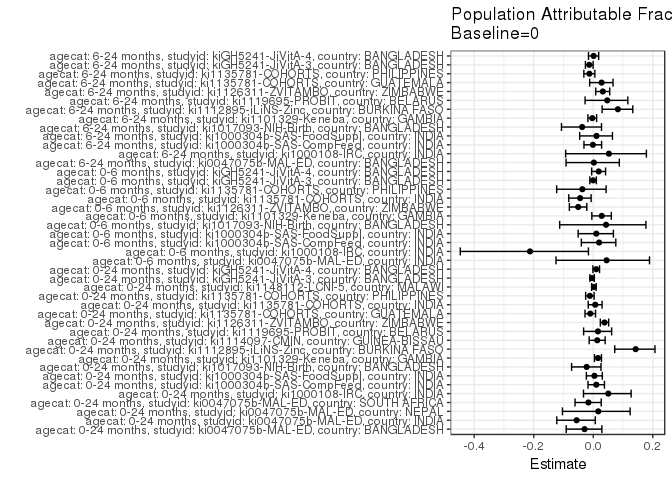

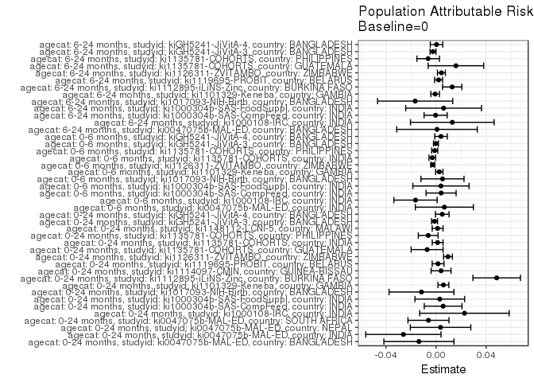

## Results Table

### Parameter: TSM

| agecat | studyid | country | intervention_level | baseline_level | estimate | ci_lower | ci_upper |
| --- | --- | --- | --- | --- | --- | --- | --- |
| 0-24 months | ki0047075b-MAL-ED | BANGLADESH | 0 | NA | 0.4825871 | 0.4133626 | 0.5518115 |
| 0-24 months | ki0047075b-MAL-ED | BANGLADESH | 1 | NA | 0.4000000 | 0.2478659 | 0.5521341 |
| 0-24 months | ki0047075b-MAL-ED | INDIA | 0 | NA | 0.4941176 | 0.4187759 | 0.5694594 |
| 0-24 months | ki0047075b-MAL-ED | INDIA | 1 | NA | 0.3333333 | 0.1720991 | 0.4945675 |
| 0-24 months | ki0047075b-MAL-ED | NEPAL | 0 | NA | 0.2094595 | 0.1437061 | 0.2752128 |
| 0-24 months | ki0047075b-MAL-ED | NEPAL | 1 | NA | 0.2380952 | 0.0553892 | 0.4208013 |
| 0-24 months | ki0047075b-MAL-ED | SOUTH AFRICA | 0 | NA | 0.3791667 | 0.3176657 | 0.4406676 |
| 0-24 months | ki0047075b-MAL-ED | SOUTH AFRICA | 1 | NA | 0.3000000 | 0.0987761 | 0.5012239 |
| 0-24 months | ki1000108-IRC | INDIA | 0 | NA | 0.4257813 | 0.3651327 | 0.4864298 |
| 0-24 months | ki1000108-IRC | INDIA | 1 | NA | 0.4924242 | 0.4070274 | 0.5778211 |
| 0-24 months | ki1000304b-SAS-CompFeed | INDIA | 0 | NA | 0.5415638 | 0.4931545 | 0.5899731 |
| 0-24 months | ki1000304b-SAS-CompFeed | INDIA | 1 | NA | 0.5921053 | 0.4690090 | 0.7152015 |
| 0-24 months | ki1000304b-SAS-FoodSuppl | INDIA | 0 | NA | 0.7371601 | 0.6896814 | 0.7846388 |
| 0-24 months | ki1000304b-SAS-FoodSuppl | INDIA | 1 | NA | 0.7534247 | 0.6544282 | 0.8524211 |
| 0-24 months | ki1017093-NIH-Birth | BANGLADESH | 0 | NA | 0.5368171 | 0.4891453 | 0.5844889 |
| 0-24 months | ki1017093-NIH-Birth | BANGLADESH | 1 | NA | 0.4971429 | 0.4230022 | 0.5712835 |
| 0-24 months | ki1101329-Keneba | GAMBIA | 0 | NA | 0.3641324 | 0.3461417 | 0.3821231 |
| 0-24 months | ki1101329-Keneba | GAMBIA | 1 | NA | 0.4768212 | 0.3971434 | 0.5564990 |
| 0-24 months | ki1112895-iLiNS-Zinc | BURKINA FASO | 0 | NA | 0.2918569 | 0.2311381 | 0.3525757 |
| 0-24 months | ki1112895-iLiNS-Zinc | BURKINA FASO | 1 | NA | 0.5786517 | 0.5107642 | 0.6465392 |
| 0-24 months | ki1114097-CMIN | GUINEA-BISSAU | 0 | NA | 0.2924731 | 0.2510836 | 0.3338626 |
| 0-24 months | ki1114097-CMIN | GUINEA-BISSAU | 1 | NA | 0.4285714 | 0.1690755 | 0.6880673 |
| 0-24 months | ki1119695-PROBIT | BELARUS | 0 | NA | 0.0978420 | 0.0814975 | 0.1141865 |
| 0-24 months | ki1119695-PROBIT | BELARUS | 1 | NA | 0.1052274 | 0.0808582 | 0.1295966 |
| 0-24 months | ki1126311-ZVITAMBO | ZIMBABWE | 0 | NA | 0.2423045 | 0.2342541 | 0.2503549 |
| 0-24 months | ki1126311-ZVITAMBO | ZIMBABWE | 1 | NA | 0.2981672 | 0.2792098 | 0.3171246 |
| 0-24 months | ki1135781-COHORTS | GUATEMALA | 0 | NA | 0.7312296 | 0.7025548 | 0.7599044 |
| 0-24 months | ki1135781-COHORTS | GUATEMALA | 1 | NA | 0.6923077 | 0.6295572 | 0.7550582 |
| 0-24 months | ki1135781-COHORTS | INDIA | 0 | NA | 0.1850540 | 0.1749246 | 0.1951834 |
| 0-24 months | ki1135781-COHORTS | INDIA | 1 | NA | 0.1919935 | 0.1699266 | 0.2140603 |

[output cut: 56 more lines]

### Parameter: E(Y)

| agecat | studyid | country | intervention_level | baseline_level | estimate | ci_lower | ci_upper |
| --- | --- | --- | --- | --- | --- | --- | --- |
| 0-24 months | ki0047075b-MAL-ED | BANGLADESH | NA | NA | 0.4688797 | 0.4057447 | 0.5320146 |
| 0-24 months | ki0047075b-MAL-ED | INDIA | NA | NA | 0.4679803 | 0.3991705 | 0.5367901 |
| 0-24 months | ki0047075b-MAL-ED | NEPAL | NA | NA | 0.2130178 | 0.1511045 | 0.2749310 |
| 0-24 months | ki0047075b-MAL-ED | SOUTH AFRICA | NA | NA | 0.3730769 | 0.3141784 | 0.4319755 |
| 0-24 months | ki1000108-IRC | INDIA | NA | NA | 0.4484536 | 0.3989038 | 0.4980035 |
| 0-24 months | ki1000304b-SAS-CompFeed | INDIA | NA | NA | 0.5471836 | 0.5012688 | 0.5930984 |
| 0-24 months | ki1000304b-SAS-FoodSuppl | INDIA | NA | NA | 0.7400990 | 0.6972792 | 0.7829188 |
| 0-24 months | ki1017093-NIH-Birth | BANGLADESH | NA | NA | 0.5251678 | 0.4850434 | 0.5652922 |
| 0-24 months | ki1101329-Keneba | GAMBIA | NA | NA | 0.3700000 | 0.3524250 | 0.3875750 |
| 0-24 months | ki1112895-iLiNS-Zinc | BURKINA FASO | NA | NA | 0.3402910 | 0.2902222 | 0.3903597 |
| 0-24 months | ki1114097-CMIN | GUINEA-BISSAU | NA | NA | 0.2964509 | 0.2555100 | 0.3373919 |
| 0-24 months | ki1119695-PROBIT | BELARUS | NA | NA | 0.0994093 | 0.0831494 | 0.1156692 |
| 0-24 months | ki1126311-ZVITAMBO | ZIMBABWE | NA | NA | 0.2518293 | 0.2444016 | 0.2592569 |
| 0-24 months | ki1135781-COHORTS | GUATEMALA | NA | NA | 0.7240461 | 0.6979377 | 0.7501545 |
| 0-24 months | ki1135781-COHORTS | INDIA | NA | NA | 0.1862902 | 0.1770836 | 0.1954968 |
| 0-24 months | ki1135781-COHORTS | PHILIPPINES | NA | NA | 0.5571968 | 0.5391496 | 0.5752441 |
| 0-24 months | ki1148112-LCNI-5 | MALAWI | NA | NA | 0.5719468 | 0.5382037 | 0.6056899 |
| 0-24 months | kiGH5241-JiVitA-3 | BANGLADESH | NA | NA | 0.3276966 | 0.3200516 | 0.3353416 |
| 0-24 months | kiGH5241-JiVitA-4 | BANGLADESH | NA | NA | 0.4898224 | 0.4725918 | 0.5070530 |
| 0-6 months | ki0047075b-MAL-ED | INDIA | NA | NA | 0.1477833 | 0.0988437 | 0.1967228 |
| 0-6 months | ki1000108-IRC | INDIA | NA | NA | 0.0773196 | 0.0507085 | 0.1039307 |
| 0-6 months | ki1000304b-SAS-CompFeed | INDIA | NA | NA | 0.2048281 | 0.1851668 | 0.2244894 |
| 0-6 months | ki1000304b-SAS-FoodSuppl | INDIA | NA | NA | 0.3796526 | 0.3322125 | 0.4270927 |
| 0-6 months | ki1017093-NIH-Birth | BANGLADESH | NA | NA | 0.1191275 | 0.0930988 | 0.1451562 |
| 0-6 months | ki1101329-Keneba | GAMBIA | NA | NA | 0.0893878 | 0.0780882 | 0.1006873 |
| 0-6 months | ki1126311-ZVITAMBO | ZIMBABWE | NA | NA | 0.0533577 | 0.0495118 | 0.0572037 |
| 0-6 months | ki1135781-COHORTS | INDIA | NA | NA | 0.0693274 | 0.0632740 | 0.0753808 |
| 0-6 months | ki1135781-COHORTS | PHILIPPINES | NA | NA | 0.0295431 | 0.0233911 | 0.0356951 |
| 0-6 months | kiGH5241-JiVitA-3 | BANGLADESH | NA | NA | 0.1805041 | 0.1749565 | 0.1860517 |
| 0-6 months | kiGH5241-JiVitA-4 | BANGLADESH | NA | NA | 0.2136196 | 0.2001838 | 0.2270554 |
| 6-24 months | ki0047075b-MAL-ED | BANGLADESH | NA | NA | 0.3602151 | 0.2910383 | 0.4293918 |
| 6-24 months | ki1000108-IRC | INDIA | NA | NA | 0.2469136 | 0.1998872 | 0.2939400 |
| 6-24 months | ki1000304b-SAS-CompFeed | INDIA | NA | NA | 0.3124324 | 0.2808301 | 0.3440347 |
| 6-24 months | ki1000304b-SAS-FoodSuppl | INDIA | NA | NA | 0.5504587 | 0.4842728 | 0.6166446 |
| 6-24 months | ki1017093-NIH-Birth | BANGLADESH | NA | NA | 0.4476886 | 0.3995563 | 0.4958208 |
| 6-24 months | ki1101329-Keneba | GAMBIA | NA | NA | 0.2342761 | 0.2172169 | 0.2513352 |
| 6-24 months | ki1112895-iLiNS-Zinc | BURKINA FASO | NA | NA | 0.1555985 | 0.1280985 | 0.1830984 |
| 6-24 months | ki1119695-PROBIT | BELARUS | NA | NA | 0.0428289 | 0.0325550 | 0.0531028 |
| 6-24 months | ki1126311-ZVITAMBO | ZIMBABWE | NA | NA | 0.1335298 | 0.1264315 | 0.1406281 |
| 6-24 months | ki1135781-COHORTS | GUATEMALA | NA | NA | 0.5675676 | 0.5248634 | 0.6102718 |
| 6-24 months | ki1135781-COHORTS | PHILIPPINES | NA | NA | 0.4884793 | 0.4674428 | 0.5095157 |
| 6-24 months | kiGH5241-JiVitA-3 | BANGLADESH | NA | NA | 0.1841492 | 0.1759877 | 0.1923107 |
| 6-24 months | kiGH5241-JiVitA-4 | BANGLADESH | NA | NA | 0.2909471 | 0.2737460 | 0.3081483 |

### Parameter: RR

| agecat | studyid | country | intervention_level | baseline_level | estimate | ci_lower | ci_upper |
| --- | --- | --- | --- | --- | --- | --- | --- |
| 0-24 months | ki0047075b-MAL-ED | BANGLADESH | 0 | 0 | 1.0000000 | 1.0000000 | 1.0000000 |
| 0-24 months | ki0047075b-MAL-ED | BANGLADESH | 1 | 0 | 0.8288660 | 0.5520132 | 1.2445695 |
| 0-24 months | ki0047075b-MAL-ED | INDIA | 0 | 0 | 1.0000000 | 1.0000000 | 1.0000000 |
| 0-24 months | ki0047075b-MAL-ED | INDIA | 1 | 0 | 0.6746032 | 0.4062458 | 1.1202318 |
| 0-24 months | ki0047075b-MAL-ED | NEPAL | 0 | 0 | 1.0000000 | 1.0000000 | 1.0000000 |
| 0-24 months | ki0047075b-MAL-ED | NEPAL | 1 | 0 | 1.1367127 | 0.4961127 | 2.6044807 |
| 0-24 months | ki0047075b-MAL-ED | SOUTH AFRICA | 0 | 0 | 1.0000000 | 1.0000000 | 1.0000000 |
| 0-24 months | ki0047075b-MAL-ED | SOUTH AFRICA | 1 | 0 | 0.7912088 | 0.3968199 | 1.5775705 |
| 0-24 months | ki1000108-IRC | INDIA | 0 | 0 | 1.0000000 | 1.0000000 | 1.0000000 |
| 0-24 months | ki1000108-IRC | INDIA | 1 | 0 | 1.1565193 | 0.9240354 | 1.4474954 |
| 0-24 months | ki1000304b-SAS-CompFeed | INDIA | 0 | 0 | 1.0000000 | 1.0000000 | 1.0000000 |
| 0-24 months | ki1000304b-SAS-CompFeed | INDIA | 1 | 0 | 1.0933251 | 0.8784829 | 1.3607091 |
| 0-24 months | ki1000304b-SAS-FoodSuppl | INDIA | 0 | 0 | 1.0000000 | 1.0000000 | 1.0000000 |
| 0-24 months | ki1000304b-SAS-FoodSuppl | INDIA | 1 | 0 | 1.0220638 | 0.8829311 | 1.1831210 |
| 0-24 months | ki1017093-NIH-Birth | BANGLADESH | 0 | 0 | 1.0000000 | 1.0000000 | 1.0000000 |
| 0-24 months | ki1017093-NIH-Birth | BANGLADESH | 1 | 0 | 0.9260936 | 0.7785271 | 1.1016306 |
| 0-24 months | ki1101329-Keneba | GAMBIA | 0 | 0 | 1.0000000 | 1.0000000 | 1.0000000 |
| 0-24 months | ki1101329-Keneba | GAMBIA | 1 | 0 | 1.3094720 | 1.1000667 | 1.5587390 |
| 0-24 months | ki1112895-iLiNS-Zinc | BURKINA FASO | 0 | 0 | 1.0000000 | 1.0000000 | 1.0000000 |
| 0-24 months | ki1112895-iLiNS-Zinc | BURKINA FASO | 1 | 0 | 1.9826553 | 1.5447768 | 2.5446537 |
| 0-24 months | ki1114097-CMIN | GUINEA-BISSAU | 0 | 0 | 1.0000000 | 1.0000000 | 1.0000000 |
| 0-24 months | ki1114097-CMIN | GUINEA-BISSAU | 1 | 0 | 1.4653361 | 0.7868455 | 2.7288839 |
| 0-24 months | ki1119695-PROBIT | BELARUS | 0 | 0 | 1.0000000 | 1.0000000 | 1.0000000 |
| 0-24 months | ki1119695-PROBIT | BELARUS | 1 | 0 | 1.0754833 | 0.8740008 | 1.3234133 |
| 0-24 months | ki1126311-ZVITAMBO | ZIMBABWE | 0 | 0 | 1.0000000 | 1.0000000 | 1.0000000 |
| 0-24 months | ki1126311-ZVITAMBO | ZIMBABWE | 1 | 0 | 1.2305474 | 1.1453632 | 1.3220670 |
| 0-24 months | ki1135781-COHORTS | GUATEMALA | 0 | 0 | 1.0000000 | 1.0000000 | 1.0000000 |
| 0-24 months | ki1135781-COHORTS | GUATEMALA | 1 | 0 | 0.9467720 | 0.8577386 | 1.0450470 |
| 0-24 months | ki1135781-COHORTS | INDIA | 0 | 0 | 1.0000000 | 1.0000000 | 1.0000000 |
| 0-24 months | ki1135781-COHORTS | INDIA | 1 | 0 | 1.0374996 | 0.9134831 | 1.1783529 |

[output cut: 56 more lines]

### Parameter: PAR

| agecat | studyid | country | intervention_level | baseline_level | estimate | ci_lower | ci_upper |
| --- | --- | --- | --- | --- | --- | --- | --- |
| 0-24 months | ki0047075b-MAL-ED | BANGLADESH | 0 | NA | -0.0137074 | -0.0417200 | 0.0143052 |
| 0-24 months | ki0047075b-MAL-ED | INDIA | 0 | NA | -0.0261374 | -0.0562027 | 0.0039280 |
| 0-24 months | ki0047075b-MAL-ED | NEPAL | 0 | NA | 0.0035583 | -0.0206125 | 0.0277291 |
| 0-24 months | ki0047075b-MAL-ED | SOUTH AFRICA | 0 | NA | -0.0060897 | -0.0224780 | 0.0102985 |
| 0-24 months | ki1000108-IRC | INDIA | 0 | NA | 0.0226724 | -0.0131001 | 0.0584448 |
| 0-24 months | ki1000304b-SAS-CompFeed | INDIA | 0 | NA | 0.0056198 | -0.0094686 | 0.0207083 |
| 0-24 months | ki1000304b-SAS-FoodSuppl | INDIA | 0 | NA | 0.0029389 | -0.0169094 | 0.0227871 |
| 0-24 months | ki1017093-NIH-Birth | BANGLADESH | 0 | NA | -0.0116493 | -0.0375713 | 0.0142727 |
| 0-24 months | ki1101329-Keneba | GAMBIA | 0 | NA | 0.0058676 | 0.0015179 | 0.0102173 |
| 0-24 months | ki1112895-iLiNS-Zinc | BURKINA FASO | 0 | NA | 0.0484340 | 0.0294568 | 0.0674113 |
| 0-24 months | ki1114097-CMIN | GUINEA-BISSAU | 0 | NA | 0.0039778 | -0.0039727 | 0.0119283 |
| 0-24 months | ki1119695-PROBIT | BELARUS | 0 | NA | 0.0015673 | -0.0031351 | 0.0062698 |
| 0-24 months | ki1126311-ZVITAMBO | ZIMBABWE | 0 | NA | 0.0095248 | 0.0059947 | 0.0130548 |
| 0-24 months | ki1135781-COHORTS | GUATEMALA | 0 | NA | -0.0071835 | -0.0199471 | 0.0055802 |
| 0-24 months | ki1135781-COHORTS | INDIA | 0 | NA | 0.0012362 | -0.0030896 | 0.0055620 |
| 0-24 months | ki1135781-COHORTS | PHILIPPINES | 0 | NA | -0.0062985 | -0.0141888 | 0.0015919 |
| 0-24 months | ki1148112-LCNI-5 | MALAWI | 0 | NA | 0.0012211 | -0.0031160 | 0.0055582 |
| 0-24 months | kiGH5241-JiVitA-3 | BANGLADESH | 0 | NA | -0.0012481 | -0.0036530 | 0.0011568 |
| 0-24 months | kiGH5241-JiVitA-4 | BANGLADESH | 0 | NA | 0.0049235 | -0.0005350 | 0.0103820 |
| 0-6 months | ki0047075b-MAL-ED | INDIA | 0 | NA | 0.0066068 | -0.0165648 | 0.0297784 |
| 0-6 months | ki1000108-IRC | INDIA | 0 | NA | -0.0164304 | -0.0337410 | 0.0008802 |
| 0-6 months | ki1000304b-SAS-CompFeed | INDIA | 0 | NA | 0.0040050 | -0.0079996 | 0.0160097 |
| 0-6 months | ki1000304b-SAS-FoodSuppl | INDIA | 0 | NA | 0.0038950 | -0.0185759 | 0.0263659 |
| 0-6 months | ki1017093-NIH-Birth | BANGLADESH | 0 | NA | 0.0051133 | -0.0121033 | 0.0223298 |
| 0-6 months | ki1101329-Keneba | GAMBIA | 0 | NA | 0.0025423 | -0.0003960 | 0.0054806 |
| 0-6 months | ki1126311-ZVITAMBO | ZIMBABWE | 0 | NA | -0.0026981 | -0.0042735 | -0.0011228 |
| 0-6 months | ki1135781-COHORTS | INDIA | 0 | NA | -0.0030528 | -0.0056655 | -0.0004402 |
| 0-6 months | ki1135781-COHORTS | PHILIPPINES | 0 | NA | -0.0010816 | -0.0035415 | 0.0013783 |
| 0-6 months | kiGH5241-JiVitA-3 | BANGLADESH | 0 | NA | -0.0000918 | -0.0020612 | 0.0018777 |
| 0-6 months | kiGH5241-JiVitA-4 | BANGLADESH | 0 | NA | 0.0039076 | -0.0011018 | 0.0089171 |
| 6-24 months | ki0047075b-MAL-ED | BANGLADESH | 0 | NA | 0.0007379 | -0.0314415 | 0.0329174 |
| 6-24 months | ki1000108-IRC | INDIA | 0 | NA | 0.0129686 | -0.0204446 | 0.0463819 |
| 6-24 months | ki1000304b-SAS-CompFeed | INDIA | 0 | NA | -0.0003695 | -0.0096131 | 0.0088741 |
| 6-24 months | ki1000304b-SAS-FoodSuppl | INDIA | 0 | NA | 0.0060143 | -0.0242647 | 0.0362932 |
| 6-24 months | ki1017093-NIH-Birth | BANGLADESH | 0 | NA | -0.0167182 | -0.0467619 | 0.0133255 |
| 6-24 months | ki1101329-Keneba | GAMBIA | 0 | NA | -0.0007591 | -0.0041941 | 0.0026758 |
| 6-24 months | ki1112895-iLiNS-Zinc | BURKINA FASO | 0 | NA | 0.0128680 | 0.0051796 | 0.0205563 |
| 6-24 months | ki1119695-PROBIT | BELARUS | 0 | NA | 0.0020145 | -0.0011982 | 0.0052271 |
| 6-24 months | ki1126311-ZVITAMBO | ZIMBABWE | 0 | NA | 0.0042826 | 0.0011242 | 0.0074411 |
| 6-24 months | ki1135781-COHORTS | GUATEMALA | 0 | NA | 0.0158434 | -0.0063581 | 0.0380449 |
| 6-24 months | ki1135781-COHORTS | PHILIPPINES | 0 | NA | -0.0063380 | -0.0153495 | 0.0026735 |
| 6-24 months | kiGH5241-JiVitA-3 | BANGLADESH | 0 | NA | -0.0024492 | -0.0048237 | -0.0000748 |
| 6-24 months | kiGH5241-JiVitA-4 | BANGLADESH | 0 | NA | 0.0003489 | -0.0046383 | 0.0053360 |

### Parameter: PAF

| agecat | studyid | country | intervention_level | baseline_level | estimate | ci_lower | ci_upper |
| --- | --- | --- | --- | --- | --- | --- | --- |
| 0-24 months | ki0047075b-MAL-ED | BANGLADESH | 0 | NA | -0.0292344 | -0.0908584 | 0.0289084 |
| 0-24 months | ki0047075b-MAL-ED | INDIA | 0 | NA | -0.0558514 | -0.1225677 | 0.0068999 |
| 0-24 months | ki0047075b-MAL-ED | NEPAL | 0 | NA | 0.0167042 | -0.1035161 | 0.1238274 |
| 0-24 months | ki0047075b-MAL-ED | SOUTH AFRICA | 0 | NA | -0.0163230 | -0.0612299 | 0.0266835 |
| 0-24 months | ki1000108-IRC | INDIA | 0 | NA | 0.0505568 | -0.0327740 | 0.1271639 |
| 0-24 months | ki1000304b-SAS-CompFeed | INDIA | 0 | NA | 0.0102705 | -0.0177108 | 0.0374824 |
| 0-24 months | ki1000304b-SAS-FoodSuppl | INDIA | 0 | NA | 0.0039709 | -0.0232165 | 0.0304360 |
| 0-24 months | ki1017093-NIH-Birth | BANGLADESH | 0 | NA | -0.0221821 | -0.0727912 | 0.0260396 |
| 0-24 months | ki1101329-Keneba | GAMBIA | 0 | NA | 0.0158583 | 0.0040280 | 0.0275481 |
| 0-24 months | ki1112895-iLiNS-Zinc | BURKINA FASO | 0 | NA | 0.1423312 | 0.0721043 | 0.2072431 |
| 0-24 months | ki1114097-CMIN | GUINEA-BISSAU | 0 | NA | 0.0134181 | -0.0137576 | 0.0398654 |
| 0-24 months | ki1119695-PROBIT | BELARUS | 0 | NA | 0.0157663 | -0.0324233 | 0.0617066 |
| 0-24 months | ki1126311-ZVITAMBO | ZIMBABWE | 0 | NA | 0.0378223 | 0.0237180 | 0.0517228 |
| 0-24 months | ki1135781-COHORTS | GUATEMALA | 0 | NA | -0.0099213 | -0.0277202 | 0.0075694 |
| 0-24 months | ki1135781-COHORTS | INDIA | 0 | NA | 0.0066359 | -0.0168572 | 0.0295861 |
| 0-24 months | ki1135781-COHORTS | PHILIPPINES | 0 | NA | -0.0113038 | -0.0255717 | 0.0027655 |
| 0-24 months | ki1148112-LCNI-5 | MALAWI | 0 | NA | 0.0021350 | -0.0054787 | 0.0096910 |
| 0-24 months | kiGH5241-JiVitA-3 | BANGLADESH | 0 | NA | -0.0038087 | -0.0111799 | 0.0035089 |
| 0-24 months | kiGH5241-JiVitA-4 | BANGLADESH | 0 | NA | 0.0100516 | -0.0011597 | 0.0211374 |
| 0-6 months | ki0047075b-MAL-ED | INDIA | 0 | NA | 0.0447059 | -0.1251384 | 0.1889115 |
| 0-6 months | ki1000108-IRC | INDIA | 0 | NA | -0.2125000 | -0.4467306 | -0.0161921 |
| 0-6 months | ki1000304b-SAS-CompFeed | INDIA | 0 | NA | 0.0195532 | -0.0400263 | 0.0757196 |
| 0-6 months | ki1000304b-SAS-FoodSuppl | INDIA | 0 | NA | 0.0102595 | -0.0507373 | 0.0677153 |
| 0-6 months | ki1017093-NIH-Birth | BANGLADESH | 0 | NA | 0.0429226 | -0.1128195 | 0.1768682 |
| 0-6 months | ki1101329-Keneba | GAMBIA | 0 | NA | 0.0284411 | -0.0048276 | 0.0606084 |
| 0-6 months | ki1126311-ZVITAMBO | ZIMBABWE | 0 | NA | -0.0505671 | -0.0803051 | -0.0216478 |
| 0-6 months | ki1135781-COHORTS | INDIA | 0 | NA | -0.0440352 | -0.0822377 | -0.0071812 |
| 0-6 months | ki1135781-COHORTS | PHILIPPINES | 0 | NA | -0.0366120 | -0.1229568 | 0.0430937 |
| 0-6 months | kiGH5241-JiVitA-3 | BANGLADESH | 0 | NA | -0.0005084 | -0.0114798 | 0.0103440 |
| 0-6 months | kiGH5241-JiVitA-4 | BANGLADESH | 0 | NA | 0.0182925 | -0.0053604 | 0.0413889 |
| 6-24 months | ki0047075b-MAL-ED | BANGLADESH | 0 | NA | 0.0020486 | -0.0914061 | 0.0875010 |
| 6-24 months | ki1000108-IRC | INDIA | 0 | NA | 0.0525229 | -0.0927799 | 0.1785054 |
| 6-24 months | ki1000304b-SAS-CompFeed | INDIA | 0 | NA | -0.0011827 | -0.0312458 | 0.0280040 |
| 6-24 months | ki1000304b-SAS-FoodSuppl | INDIA | 0 | NA | 0.0109259 | -0.0456628 | 0.0644522 |
| 6-24 months | ki1017093-NIH-Birth | BANGLADESH | 0 | NA | -0.0373434 | -0.1067575 | 0.0277171 |
| 6-24 months | ki1101329-Keneba | GAMBIA | 0 | NA | -0.0032404 | -0.0180092 | 0.0113142 |
| 6-24 months | ki1112895-iLiNS-Zinc | BURKINA FASO | 0 | NA | 0.0826998 | 0.0297471 | 0.1327625 |
| 6-24 months | ki1119695-PROBIT | BELARUS | 0 | NA | 0.0470354 | -0.0274724 | 0.1161402 |
| 6-24 months | ki1126311-ZVITAMBO | ZIMBABWE | 0 | NA | 0.0320726 | 0.0081722 | 0.0553970 |
| 6-24 months | ki1135781-COHORTS | GUATEMALA | 0 | NA | 0.0279146 | -0.0120910 | 0.0663389 |
| 6-24 months | ki1135781-COHORTS | PHILIPPINES | 0 | NA | -0.0129749 | -0.0316001 | 0.0053140 |
| 6-24 months | kiGH5241-JiVitA-3 | BANGLADESH | 0 | NA | -0.0133003 | -0.0263073 | -0.0004581 |
| 6-24 months | kiGH5241-JiVitA-4 | BANGLADESH | 0 | NA | 0.0011990 | -0.0160864 | 0.0181904 |